# **Featurization, Model Selection and Tuning Project Solution**

• DOMAIN: Semiconductor manufacturing process

• CONTEXT: A complex modern semiconductor manufacturing process is normally under constant surveillance via the monitoring of signals/variables collected from sensors and or process measurement points. However, not all of these signals are equally valuable in a specific monitoring system. The measured signals contain a combination of useful information, irrelevant information as well as noise. Engineers typically have a much larger number of signals than are actually required. If we consider each type of signal as a feature, then feature selection may be applied to identify the most relevant signals. The Process Engineers may then use these signals to determine key factors contributing to yield excursions downstream in the process. This will enable an increase in process throughput, decreased time to learning and reduce the per unit production costs. These signals can be used as features to predict the yield type. And by analysing and trying out different combinations of features, essential signals that are impacting the yield type can be identified.

• DATA DESCRIPTION: sensor-data.csv : (1567, 592) The data consists of 1567 datapoints each with 591 features. The dataset presented in this case represents a selection of such features where each example represents a single production entity with associated measured features and the labels represent a simple pass/fail yield for in house line testing. Target column “ –1” corresponds to a pass and “1” corresponds to a fail and the data time stamp is for that specific test point.

• PROJECT OBJECTIVE: We will build a classifier to predict the Pass/Fail yield of a particular process entity and analyse whether all the features are required to build the model or not.

## **1. Import and understand the data.**

```python
# Import all the necessary libraries.
import pandas as pd
import numpy as np
import seaborn as sns
import matplotlib.pyplot as plt
%matplotlib inline
import warnings
warnings.filterwarnings('ignore')
```

**A. Import ‘signal-data.csv’ as DataFrame.**

```python
df_base = pd.read_csv('signal-data.csv')
```

```python
print(df_base.shape)
```

```
(1567, 592)
```

**Observation:**

The Data Frame has 1567 rows and 592 features.

```python
df_base.head()
```

|  | Time | 0 | 1 | 2 | 3 | 4 | 5 | 6 | 7 | 8 | ... | 581 | 582 | 583 | 584 | 585 | 586 | 587 | 588 | 589 | Pass/Fail |
| --- | --- | --- | --- | --- | --- | --- | --- | --- | --- | --- | --- | --- | --- | --- | --- | --- | --- | --- | --- | --- | --- |
| 0 | 2008-07-19 11:55:00 | 3030.93 | 2564.00 | 2187.7333 | 1411.1265 | 1.3602 | 100.0 | 97.6133 | 0.1242 | 1.5005 | ... | NaN | 0.5005 | 0.0118 | 0.0035 | 2.3630 | NaN | NaN | NaN | NaN | -1 |
| 1 | 2008-07-19 12:32:00 | 3095.78 | 2465.14 | 2230.4222 | 1463.6606 | 0.8294 | 100.0 | 102.3433 | 0.1247 | 1.4966 | ... | 208.2045 | 0.5019 | 0.0223 | 0.0055 | 4.4447 | 0.0096 | 0.0201 | 0.0060 | 208.2045 | -1 |
| 2 | 2008-07-19 13:17:00 | 2932.61 | 2559.94 | 2186.4111 | 1698.0172 | 1.5102 | 100.0 | 95.4878 | 0.1241 | 1.4436 | ... | 82.8602 | 0.4958 | 0.0157 | 0.0039 | 3.1745 | 0.0584 | 0.0484 | 0.0148 | 82.8602 | 1 |
| 3 | 2008-07-19 14:43:00 | 2988.72 | 2479.90 | 2199.0333 | 909.7926 | 1.3204 | 100.0 | 104.2367 | 0.1217 | 1.4882 | ... | 73.8432 | 0.4990 | 0.0103 | 0.0025 | 2.0544 | 0.0202 | 0.0149 | 0.0044 | 73.8432 | -1 |
| 4 | 2008-07-19 15:22:00 | 3032.24 | 2502.87 | 2233.3667 | 1326.5200 | 1.5334 | 100.0 | 100.3967 | 0.1235 | 1.5031 | ... | NaN | 0.4800 | 0.4766 | 0.1045 | 99.3032 | 0.0202 | 0.0149 | 0.0044 | 73.8432 | -1 |

5 rows × 592 columns

**B. Print 5 point summary and share at least 2 observations.**

```python
# 5-point summary of the data
df_base.describe().T
```

|  | count | mean | std | min | 25% | 50% | 75% | max |
| --- | --- | --- | --- | --- | --- | --- | --- | --- |
| 0 | 1561.0 | 3014.452896 | 73.621787 | 2743.2400 | 2966.260000 | 3011.4900 | 3056.6500 | 3356.3500 |
| 1 | 1560.0 | 2495.850231 | 80.407705 | 2158.7500 | 2452.247500 | 2499.4050 | 2538.8225 | 2846.4400 |
| 2 | 1553.0 | 2200.547318 | 29.513152 | 2060.6600 | 2181.044400 | 2201.0667 | 2218.0555 | 2315.2667 |
| 3 | 1553.0 | 1396.376627 | 441.691640 | 0.0000 | 1081.875800 | 1285.2144 | 1591.2235 | 3715.0417 |
| 4 | 1553.0 | 4.197013 | 56.355540 | 0.6815 | 1.017700 | 1.3168 | 1.5257 | 1114.5366 |
| ... | ... | ... | ... | ... | ... | ... | ... | ... |
| 586 | 1566.0 | 0.021458 | 0.012358 | -0.0169 | 0.013425 | 0.0205 | 0.0276 | 0.1028 |
| 587 | 1566.0 | 0.016475 | 0.008808 | 0.0032 | 0.010600 | 0.0148 | 0.0203 | 0.0799 |
| 588 | 1566.0 | 0.005283 | 0.002867 | 0.0010 | 0.003300 | 0.0046 | 0.0064 | 0.0286 |
| 589 | 1566.0 | 99.670066 | 93.891919 | 0.0000 | 44.368600 | 71.9005 | 114.7497 | 737.3048 |
| Pass/Fail | 1567.0 | -0.867262 | 0.498010 | -1.0000 | -1.000000 | -1.0000 | -1.0000 | 1.0000 |

591 rows × 8 columns

**Observations:**

1. Majority of the variable seem to have a normal distribution.
2. Many outliers are seen in multiple instances.

## **2. Data cleansing:**

```python
# Make a Copy of the df and apply modifications on the df_copy
df_copy = df_base.copy()
```

**A. Write a for loop which will remove all the features with 20%+ Null values and impute rest with mean of the feature.**

```python
print("No. of columns containing null values")
print(len(df_copy.columns[df_copy.isna().any()]))

print("No. of columns not containing null values")
print(len(df_copy.columns[df_copy.notna().all()]))
```

```
No. of columns containing null values
538
No. of columns not containing null values
54
```

```python
for col in df_copy:
  # Calculate the percentage Null value for column
  null_prcnt = (df_copy[col].isnull().sum()/len(df_copy))*100
  # Drop the feature that has more than 20% NULL values present in them
  if null_prcnt >= 20 :
    df_copy = df_copy.drop(col, axis=1)
  # Rest cases, impute with mean value of the feature
  elif null_prcnt != 0 :
    df_copy[col]= df_copy[col].fillna(df_copy[col].mean())
```

```python
print("No. of columns containing null values")
print(len(df_copy.columns[df_copy.isna().any()]))

print("No. of columns not containing null values")
print(len(df_copy.columns[df_copy.notna().all()]))
```

```
No. of columns containing null values
0
No. of columns not containing null values
560
```

```python
print(df_copy.shape)
```

```
(1567, 560)
```

**Observation:**

32 columns had more than 20%+ Null values. They have been removed and rest features imputed with mean.

**B. Identify and drop the features which are having same value for all the rows.**

```python
df_copy = df_copy[[i for i in df_copy if df_copy[i].nunique()>1]]
```

```python
print(df_copy.shape)
```

```
(1567, 444)
```

**C. Drop other features if required using relevant functional knowledge. Clearly justify the same.**

Since we dont require time and date information for classification, let us drop time seperately.

```python
# Drop the 'Time' feature as it is not needed for classification
df_copy.drop('Time',axis=1,inplace=True)
```

**D. Check for multi-collinearity in the data and take necessary action.**

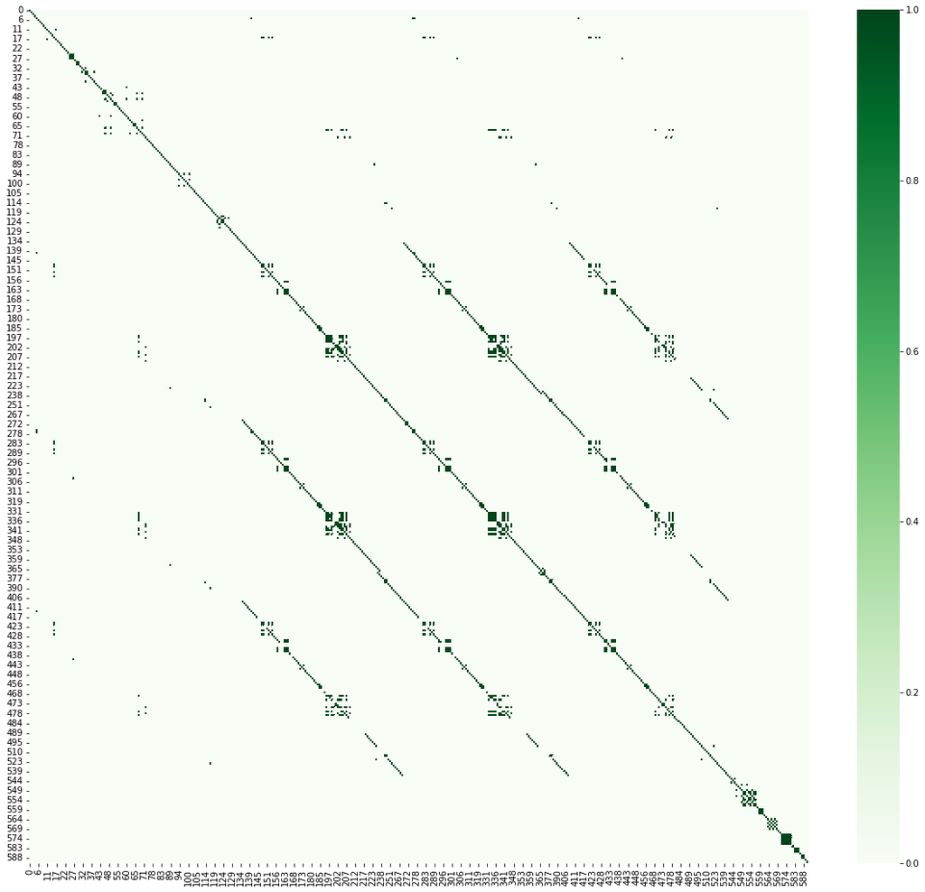

```python
# Plot map for checking the correlation between various features
plt.figure(figsize=(20,18))
corr=df_copy.corr()
sns.heatmap(abs(corr>0.7),cmap="Greens");
```

```python
#making a copy of the dataset and dropping the target class
df_corr = df_copy.copy()
df_corr.drop(['Pass/Fail'],axis=1,inplace=True)

# Create correlation matrix
corr_matrix = df_corr.corr().abs()

# Select upper triangle of correlation matrix
upper = corr_matrix.where(np.triu(np.ones(corr_matrix.shape), k=1).astype(bool))

# Find features with correlation greater than 0.70
to_drop = [column for column in upper.columns if any(upper[column] > 0.70)]

# Drop features
df_corr.drop(to_drop, axis=1, inplace=True)
```

```python
df_corr.shape
```

```
(1567, 201)
```

**Observation:**

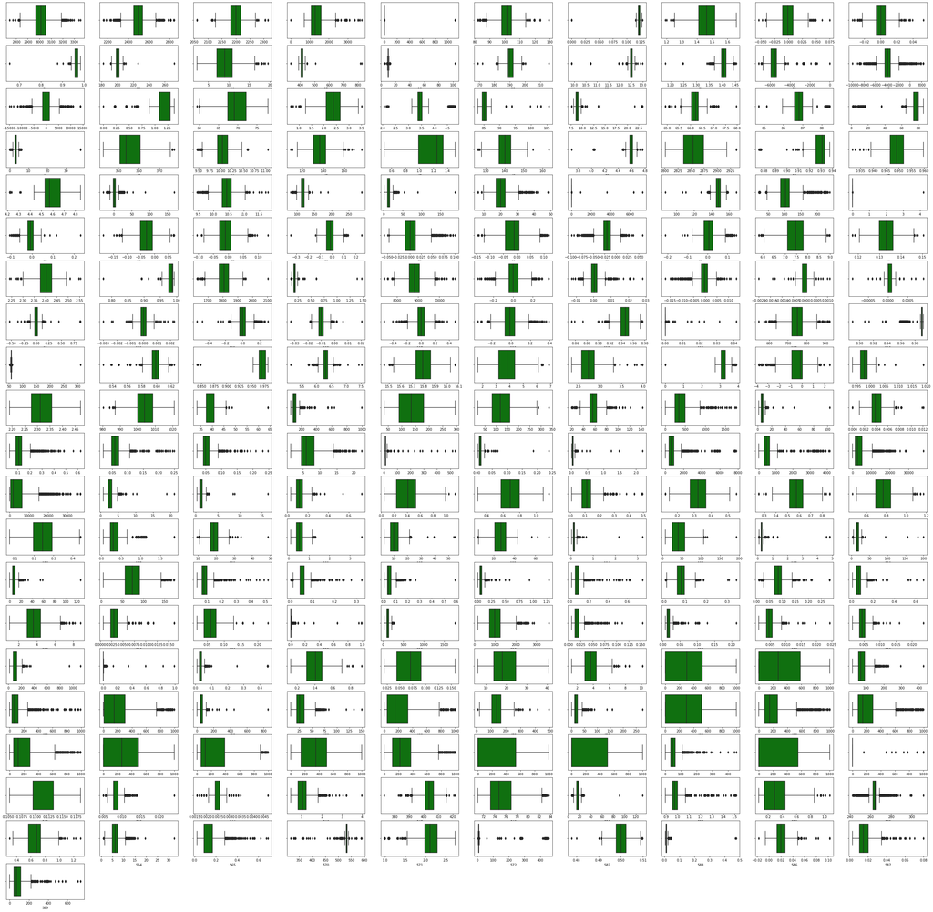

```python
#Boxplot to check for outliers
plt.figure(figsize=(50, 50))
col = 1
for i in df_corr.columns:
    plt.subplot(21,10, col)
    sns.boxplot(x = df_corr[i],color='green');
    col += 1
```

**Observation:**

Many outliers are seen with above graph. Need outlier handling.

```python
# Replace the outliers with median
for i in df_corr.columns:
  q1 = df_corr[i].quantile(0.25)
  q3 = df_corr[i].quantile(0.75)
  iqr = q3 - q1
  low = q1 - 1.5 * iqr
  high = q3 + 1.5 * iqr
  df_corr.loc[(df_corr[i] < low) | (df_corr[i] > high), i] = df_corr[i].median()
```

**E. Make all relevant modifications on the data using both functional/logical reasoning/assumptions.**

```python
# Add the target column back to the DF for further analysis
df_corr['Pass/Fail'] = df_copy['Pass/Fail']
```

"Target column “ –1” corresponds to a pass and “1” corresponds to a fail and the data time stamp is for that specific test point." Let us modify this to a standard way of treating Pass/Fail with categorical values. Change the target Pass from "-1" to "0" and let us keep Fail as "1". It is important to detect the flawed chip.

```python
df_corr['Pass/Fail'].replace({-1:0},inplace=True)
```

```python
df_corr['Pass/Fail'].unique()
```

```
array([0, 1])
```

## **3. Data analysis & visualisation:**

**A. Perform a detailed univariate Analysis with appropriate detailed comments after each analysis.**

```python
df_corr
```

|  | 0 | 1 | 2 | 3 | 4 | 6 | 7 | 8 | 9 | 10 | ... | 565 | 570 | 571 | 572 | 582 | 583 | 586 | 587 | 589 | Pass/Fail |
| --- | --- | --- | --- | --- | --- | --- | --- | --- | --- | --- | --- | --- | --- | --- | --- | --- | --- | --- | --- | --- | --- |
| 0 | 3030.93 | 2564.00 | 2187.7333 | 1411.1265 | 1.3602 | 97.6133 | 0.1242 | 1.500500 | 0.016200 | -0.003400 | ... | 0.14561 | 533.8500 | 2.1113 | 8.95 | 0.5005 | 0.0118 | 0.021458 | 0.016475 | 99.670066 | 0 |
| 1 | 3095.78 | 2465.14 | 2230.4222 | 1463.6606 | 0.8294 | 102.3433 | 0.1247 | 1.496600 | -0.000500 | -0.014800 | ... | 0.14561 | 535.0164 | 2.4335 | 5.92 | 0.5019 | 0.0223 | 0.009600 | 0.020100 | 208.204500 | 0 |
| 2 | 2932.61 | 2559.94 | 2186.4111 | 1698.0172 | 1.5102 | 95.4878 | 0.1241 | 1.443600 | 0.004100 | 0.001300 | ... | 0.14280 | 535.0245 | 2.0293 | 11.21 | 0.4958 | 0.0157 | 0.020500 | 0.014800 | 82.860200 | 1 |
| 3 | 2988.72 | 2479.90 | 2199.0333 | 909.7926 | 1.3204 | 104.2367 | 0.1217 | 1.488200 | -0.012400 | -0.003300 | ... | 0.16300 | 530.5682 | 2.0253 | 9.33 | 0.4990 | 0.0103 | 0.020200 | 0.014900 | 73.843200 | 0 |
| 4 | 3032.24 | 2502.87 | 2233.3667 | 1326.5200 | 1.5334 | 100.3967 | 0.1235 | 1.503100 | -0.003100 | -0.007200 | ... | 0.14561 | 532.0155 | 2.0275 | 8.83 | 0.5002 | 0.0138 | 0.020200 | 0.014900 | 73.843200 | 0 |
| ... | ... | ... | ... | ... | ... | ... | ... | ... | ... | ... | ... | ... | ... | ... | ... | ... | ... | ... | ... | ... | ... |
| 1562 | 2899.41 | 2464.36 | 2179.7333 | 1287.3538 | 1.4843 | 101.4922 | 0.1248 | 1.342400 | -0.004500 | -0.005700 | ... | 0.08770 | 536.3418 | 2.0153 | 7.98 | 0.4988 | 0.0143 | 0.006800 | 0.013800 | 203.172000 | 0 |
| 1563 | 3052.31 | 2522.55 | 2198.5667 | 1124.6595 | 0.8763 | 98.4689 | 0.1205 | 1.433300 | -0.006100 | -0.009300 | ... | 0.13080 | 537.9264 | 2.1814 | 5.48 | 0.4975 | 0.0131 | 0.006800 | 0.013800 | 203.172000 | 0 |
| 1564 | 2978.81 | 2379.78 | 2206.3000 | 1110.4967 | 0.8236 | 99.4122 | 0.1208 | 1.462862 | -0.000841 | 0.000146 | ... | 0.23880 | 530.3709 | 2.3435 | 6.49 | 0.4987 | 0.0153 | 0.019700 | 0.008600 | 43.523100 | 0 |
| 1565 | 2894.92 | 2532.01 | 2177.0333 | 1183.7287 | 1.5726 | 98.7978 | 0.1213 | 1.462200 | -0.007200 | 0.003200 | ... | 0.08770 | 534.3936 | 1.9098 | 9.13 | 0.5004 | 0.0178 | 0.026200 | 0.024500 | 93.494100 | 0 |
| 1566 | 2944.92 | 2450.76 | 2195.4444 | 1287.3538 | 1.5978 | 101.4922 | 0.1235 | 1.462862 | -0.000841 | 0.000146 | ... | 0.13070 | 528.7918 | 2.0831 | 6.81 | 0.4987 | 0.0181 | 0.011700 | 0.016200 | 137.784400 | 0 |

1567 rows × 202 columns

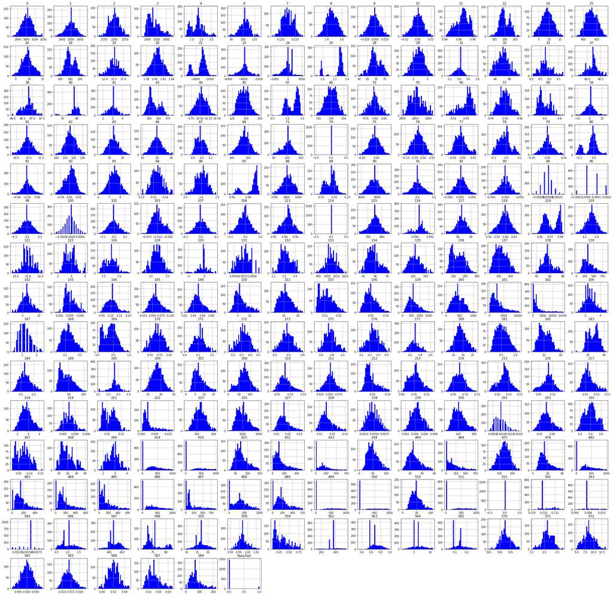

```python
#plotting histogram to check for the frequency of values within a variable
df_corr.hist(bins = 30, figsize = (40, 40), color = 'blue')
plt.show()
```

**Observations:**

Mostly features have normal distribution.

Extreme outliers are observed in many instances like feature 499, 500, 511, 482, etc.

Pass/Fail column is largely unbalanced. More instances of Success have been recorded. Failure instances are less and will need lot of handling like upsampling.

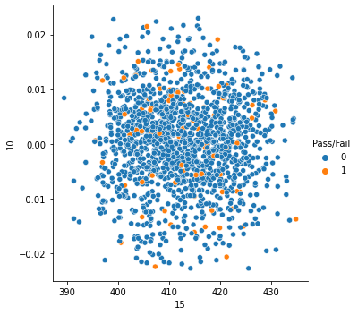

```python
sns.relplot(x = df_corr['15'], y = df_corr['10'], hue = df_corr['Pass/Fail']);
```

**B. Perform bivariate and multivariate analysis with appropriate detailed comments after each analysis.**

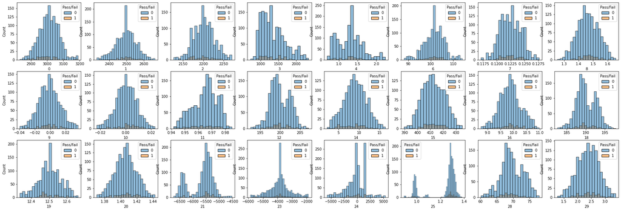

```python
#Boxplot to check for outliers
plt.figure(figsize=(30, 10))
col = 1
cols = df_corr.iloc[:,:24]
for i in cols:
    plt.subplot(3,8, col)
    sns.histplot(x = df_corr[i],hue =  df_corr['Pass/Fail']);
    col += 1
```

**Normal distribution observed mostly. As mentioned earlier, more records of Pass noted. But Failure distribution is also normally distributed.**

**In features like 25, two peaks are seen.**

## **4. Data pre-processing:**

**A. Segregate predictors vs target attributes.**

```python
# X will be the feature used to predict
X = df_corr.drop('Pass/Fail',axis=1)

# y will be the target
y = df_corr['Pass/Fail']
```

```python
from sklearn.model_selection import train_test_split

# splitting data training dataset into train and test set for independent attributes
X_train, X_test, y_train, y_test = train_test_split(X, y, test_size=.30, random_state = 123,stratify=y)
```

**B. Check for target balancing and fix it if found imbalanced.**

```python
# Lets check the Target variable distribution
y.value_counts()
```

```
0    1463
1     104
Name: Pass/Fail, dtype: int64
```

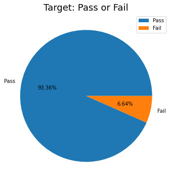

```python
# pie chart to show the distribution of target class
labels = ['Pass', 'Fail']
plt.rcParams['figure.figsize'] = (6, 6)
plt.pie(y.value_counts(), labels = labels, autopct = "%.2f%%")
plt.axis('off')
plt.title('Target: Pass or Fail', fontsize = 18)
plt.legend()
plt.show()
```

**Observation:**

The target variable is highly imbalanced class with only 6.6% failures and 93.4% pass and thus will need balancing.

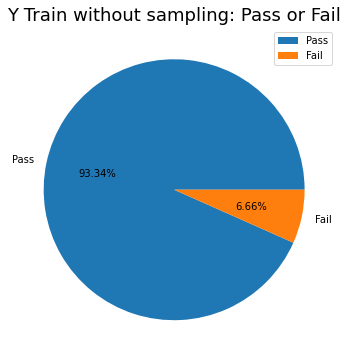

```python
# pie chart to show the distribution of target class
labels = ['Pass', 'Fail']
plt.rcParams['figure.figsize'] = (6, 6)
plt.pie(y_train.value_counts(), labels = labels, autopct = "%.2f%%")
plt.axis('off')
plt.title('Y Train without sampling: Pass or Fail', fontsize = 18)
plt.legend()
plt.show()
```

```python
from imblearn import over_sampling
from imblearn.over_sampling import SMOTE
#instantiate the sampling technique
SM = over_sampling.SMOTE()

# Sample the data
X_train_SM, y_train_SM = SM.fit_resample(X_train,y_train)
```

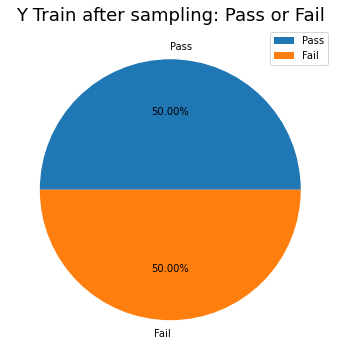

```python
# pie chart to show the distribution of target class
labels = ['Pass', 'Fail']
plt.rcParams['figure.figsize'] = (6, 6)
plt.pie(y_train_SM.value_counts(), labels = labels, autopct = "%.2f%%")
plt.axis('off')
plt.title('Y Train after sampling: Pass or Fail', fontsize = 18)
plt.legend()
plt.show()
```

**C. Perform train-test split and standardise the data or vice versa if required.**

Train test split has been done before sampling the imbalanced dataset as the balance should happen only in train data and not on test data. Now we will perform Standardization only on Train data.

```python
# Standardization of train data only
from sklearn.preprocessing import StandardScaler

# define standard scaler
scaler = StandardScaler()

# transform train data
X_train_scaled = scaler.fit_transform(X_train_SM)
```

**D. Check if the train and test data have similar statistical characteristics when compared with original data.**

```python
X.describe()
```

|  | 0 | 1 | 2 | 3 | 4 | 6 | 7 | 8 | 9 | 10 | ... | 564 | 565 | 570 | 571 | 572 | 582 | 583 | 586 | 587 | 589 |
| --- | --- | --- | --- | --- | --- | --- | --- | --- | --- | --- | --- | --- | --- | --- | --- | --- | --- | --- | --- | --- | --- |
| count | 1567.000000 | 1567.000000 | 1567.000000 | 1567.000000 | 1567.000000 | 1567.000000 | 1567.000000 | 1567.000000 | 1567.000000 | 1567.000000 | ... | 1567.000000 | 1567.000000 | 1567.000000 | 1567.000000 | 1567.000000 | 1567.000000 | 1567.000000 | 1567.000000 | 1567.000000 | 1567.000000 |
| mean | 3010.002449 | 2496.985253 | 2201.001188 | 1345.707557 | 1.296507 | 101.428935 | 0.122455 | 1.463768 | -0.001384 | 0.000149 | ... | 6.062336 | 0.134828 | 532.712749 | 2.135578 | 8.625781 | 0.500094 | 0.013891 | 0.020574 | 0.015366 | 76.511991 |
| std | 61.721903 | 59.577861 | 25.681452 | 334.300811 | 0.333287 | 4.466126 | 0.001881 | 0.072346 | 0.013846 | 0.008298 | ... | 1.652120 | 0.050040 | 2.466524 | 0.209005 | 1.668203 | 0.003241 | 0.003183 | 0.010188 | 0.006558 | 45.382032 |
| min | 2831.910000 | 2326.590000 | 2126.655500 | 711.025800 | 0.681500 | 88.091100 | 0.117100 | 1.253200 | -0.039300 | -0.022800 | ... | 1.490000 | 0.022400 | 525.242700 | 1.547300 | 4.840000 | 0.491500 | 0.006000 | -0.006000 | 0.003200 | 0.000000 |
| 25% | 2968.195000 | 2459.870000 | 2183.055600 | 1084.377900 | 1.017700 | 98.805600 | 0.121100 | 1.411650 | -0.010650 | -0.005250 | ... | 4.980000 | 0.087700 | 531.085400 | 2.007500 | 7.500000 | 0.498000 | 0.011600 | 0.013500 | 0.010600 | 44.368600 |
| 50% | 3011.840000 | 2498.910000 | 2200.955600 | 1287.353800 | 1.317100 | 101.492200 | 0.122400 | 1.461600 | -0.001300 | 0.000400 | ... | 6.290000 | 0.142800 | 532.398200 | 2.118600 | 8.650000 | 0.500200 | 0.013800 | 0.020500 | 0.014800 | 72.023000 |
| 75% | 3051.840000 | 2534.325000 | 2217.577800 | 1551.694700 | 1.490500 | 104.198900 | 0.123800 | 1.516850 | 0.007600 | 0.005700 | ... | 6.444985 | 0.150300 | 534.313600 | 2.290650 | 9.750000 | 0.502300 | 0.015800 | 0.027400 | 0.019000 | 94.415900 |
| max | 3190.970000 | 2666.040000 | 2270.255600 | 2347.909200 | 2.244900 | 113.883300 | 0.127600 | 1.656400 | 0.036200 | 0.023000 | ... | 10.790000 | 0.284000 | 539.255400 | 2.739500 | 13.810000 | 0.509000 | 0.023700 | 0.048400 | 0.034500 | 220.037800 |

8 rows × 201 columns

```python
X_train_SM.describe()
```

|  | 0 | 1 | 2 | 3 | 4 | 6 | 7 | 8 | 9 | 10 | ... | 564 | 565 | 570 | 571 | 572 | 582 | 583 | 586 | 587 | 589 |
| --- | --- | --- | --- | --- | --- | --- | --- | --- | --- | --- | --- | --- | --- | --- | --- | --- | --- | --- | --- | --- | --- |
| count | 2046.000000 | 2046.000000 | 2046.000000 | 2046.000000 | 2046.000000 | 2046.000000 | 2046.000000 | 2046.000000 | 2046.000000 | 2046.000000 | ... | 2046.000000 | 2046.000000 | 2046.000000 | 2046.000000 | 2046.000000 | 2046.000000 | 2046.000000 | 2046.000000 | 2046.000000 | 2046.000000 |
| mean | 3001.095208 | 2498.495977 | 2198.586557 | 1331.910036 | 1.290985 | 101.147539 | 0.122372 | 1.467470 | -0.001038 | 0.000563 | ... | 6.150123 | 0.140325 | 532.809140 | 2.157454 | 8.706585 | 0.500314 | 0.013767 | 0.020473 | 0.016020 | 81.409244 |
| std | 60.908544 | 56.835739 | 23.062118 | 295.612900 | 0.288757 | 3.700973 | 0.001649 | 0.063394 | 0.012447 | 0.007663 | ... | 1.569666 | 0.045762 | 2.213475 | 0.193561 | 1.565899 | 0.003154 | 0.002873 | 0.009178 | 0.006030 | 44.914591 |
| min | 2846.070000 | 2327.290000 | 2126.655500 | 711.025800 | 0.681500 | 88.091100 | 0.117100 | 1.253200 | -0.039300 | -0.022800 | ... | 1.490000 | 0.026400 | 525.242700 | 1.555000 | 4.920000 | 0.491500 | 0.006000 | -0.006000 | 0.003200 | 0.000000 |
| 25% | 2959.214394 | 2463.239940 | 2181.004866 | 1104.924100 | 1.075763 | 99.026700 | 0.121198 | 1.426725 | -0.008900 | -0.004135 | ... | 4.980000 | 0.099966 | 531.307470 | 2.029439 | 7.682450 | 0.498400 | 0.011639 | 0.014200 | 0.011300 | 50.078400 |
| 50% | 2996.373602 | 2499.564596 | 2198.848144 | 1275.091700 | 1.317100 | 101.399216 | 0.122323 | 1.467921 | -0.001225 | 0.001000 | ... | 6.290000 | 0.142845 | 532.623824 | 2.154317 | 8.650000 | 0.500500 | 0.013530 | 0.020500 | 0.015424 | 72.023000 |
| 75% | 3039.814628 | 2533.564543 | 2213.755600 | 1530.840470 | 1.475600 | 103.473300 | 0.123500 | 1.509630 | 0.006900 | 0.005627 | ... | 6.819935 | 0.161877 | 534.341504 | 2.310276 | 9.734781 | 0.502400 | 0.015567 | 0.026737 | 0.019977 | 102.165200 |
| max | 3190.780000 | 2664.520000 | 2270.255600 | 2341.783300 | 2.232800 | 113.883300 | 0.127600 | 1.656400 | 0.036200 | 0.023000 | ... | 10.770000 | 0.284000 | 539.255400 | 2.739500 | 13.810000 | 0.509000 | 0.023400 | 0.048400 | 0.034500 | 220.037800 |

8 rows × 201 columns

```python
X_test.describe()
```

|  | 0 | 1 | 2 | 3 | 4 | 6 | 7 | 8 | 9 | 10 | ... | 564 | 565 | 570 | 571 | 572 | 582 | 583 | 586 | 587 | 589 |
| --- | --- | --- | --- | --- | --- | --- | --- | --- | --- | --- | --- | --- | --- | --- | --- | --- | --- | --- | --- | --- | --- |
| count | 471.000000 | 471.000000 | 471.000000 | 471.000000 | 471.000000 | 471.000000 | 471.000000 | 471.000000 | 471.00000 | 471.000000 | ... | 471.000000 | 471.000000 | 471.000000 | 471.000000 | 471.000000 | 471.000000 | 471.000000 | 471.000000 | 471.000000 | 471.000000 |
| mean | 3010.019457 | 2496.651764 | 2201.110179 | 1347.355092 | 1.312745 | 101.540789 | 0.122525 | 1.464878 | -0.00213 | 0.000335 | ... | 6.113787 | 0.133217 | 532.693598 | 2.130314 | 8.604033 | 0.500314 | 0.013941 | 0.020544 | 0.015436 | 76.071020 |
| std | 59.378787 | 57.241918 | 26.399619 | 337.543091 | 0.354276 | 4.864812 | 0.001872 | 0.067578 | 0.01390 | 0.008189 | ... | 1.706483 | 0.049027 | 2.542909 | 0.206335 | 1.727711 | 0.003333 | 0.003209 | 0.009924 | 0.006439 | 44.054246 |
| min | 2831.910000 | 2326.590000 | 2126.655500 | 711.025800 | 0.681500 | 88.091100 | 0.117100 | 1.289800 | -0.03760 | -0.021800 | ... | 1.490000 | 0.022400 | 525.612700 | 1.547300 | 4.840000 | 0.492200 | 0.006800 | -0.004700 | 0.004200 | 0.000000 |
| 25% | 2967.775000 | 2462.115000 | 2181.188900 | 1084.514050 | 1.017700 | 98.936700 | 0.121200 | 1.416000 | -0.01195 | -0.004600 | ... | 4.980000 | 0.087700 | 531.036400 | 2.013300 | 7.485000 | 0.498100 | 0.011600 | 0.013100 | 0.010950 | 44.813400 |
| 50% | 3011.840000 | 2498.910000 | 2200.955600 | 1287.353800 | 1.310100 | 101.492200 | 0.122500 | 1.462862 | -0.00130 | 0.000400 | ... | 6.290000 | 0.142800 | 532.398200 | 2.118600 | 8.650000 | 0.500300 | 0.013800 | 0.020100 | 0.014800 | 72.023000 |
| 75% | 3052.955000 | 2532.155000 | 2218.877800 | 1534.205300 | 1.517400 | 104.521100 | 0.123900 | 1.513600 | 0.00730 | 0.005650 | ... | 6.685000 | 0.149800 | 534.204100 | 2.265100 | 9.760000 | 0.502600 | 0.015800 | 0.027450 | 0.019100 | 91.426400 |
| max | 3190.970000 | 2666.040000 | 2269.255600 | 2347.909200 | 2.244900 | 113.427800 | 0.127600 | 1.634300 | 0.03610 | 0.022400 | ... | 10.790000 | 0.282900 | 539.069100 | 2.739500 | 13.760000 | 0.508700 | 0.023700 | 0.047300 | 0.034500 | 220.037800 |

8 rows × 201 columns

**Observation:**

X_train has similar mean as original data but SD has reduced. X_test has both mean and sd similar to original data.

## **5. Model training, testing and tuning:**

**A. Use any Supervised Learning technique to train a model.**

```python
# Apply Std Scalar on test data
X_test_scaled = scaler.transform(X_test)
```

```python
model_comparision_list = []

from sklearn.metrics import accuracy_score,confusion_matrix,precision_score,recall_score,f1_score,classification_report

# Evaluating classifier performance
def evaluate_model_perf(model_descr, x, x_pred, y, y_pred):
  print('-'*40)
  print("Classification report:")
  print(classification_report(y,y_pred))
  print('-'*40)
  print('\nTraining Data Accuracy Score:\t{:.2f} '.format(accuracy_score(x,x_pred)))
  print('\nTest Data Accuracy Score:\t{:.2f} '.format(accuracy_score(y,y_pred)))
  print('\nPrecision:\t\t\t{:.2f} '.format(precision_score(y,y_pred, average='macro')))
  print('\nRecall:\t\t\t\t{:.2f} '.format(recall_score(y,y_pred, average='macro')))
  print('\nF1 Score:\t\t\t{:.2f} '.format(f1_score(y,y_pred, average='macro')))
  print('-'*40)
  print("\nConfusion Matrix:")
  print(confusion_matrix(y,y_pred))
  print('-'*40)


  # performance_matrix list of this model
  performance_matrix = []
  performance_matrix.append(model_descr)
  performance_matrix.append(accuracy_score(x,x_pred)*100)
  performance_matrix.append(accuracy_score(y,y_pred)*100)
  performance_matrix.append(precision_score(y,y_pred, average='macro')*100)
  performance_matrix.append(recall_score(y,y_pred, average='macro')*100)
  performance_matrix.append(f1_score(y,y_pred, average='macro')*100)
  # Store the performance per model
  model_comparision_list.append(performance_matrix)

def display_model_matrix():
  final_perf_df = pd.DataFrame(model_comparision_list, columns=['Model','Train Accuracy','Test Accuracy', 'Precision','Recall','F1 Score'])
  final_perf_df.sort_values(by=['F1 Score'], inplace=True, ascending=False)

  print('-'*80)
  print("Model Performance Comparision Matrix")
  print('-'*80)
  print(final_perf_df)
  print('-'*80)
```

**Logistic Regression Model without hyperparameter tuning**

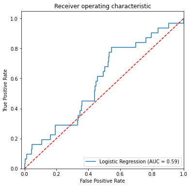

```
----------------------------------------
Classification report:
              precision    recall  f1-score   support

           0       0.94      0.85      0.89       440
           1       0.09      0.19      0.12        31

    accuracy                           0.81       471
   macro avg       0.51      0.52      0.51       471
weighted avg       0.88      0.81      0.84       471

----------------------------------------

Training Data Accuracy Score:	0.96

Test Data Accuracy Score:	0.81

Precision:			0.51

Recall:				0.52

F1 Score:			0.51
----------------------------------------

Confusion Matrix:
[[376  64]
 [ 25   6]]
----------------------------------------
```

```python
# Logistic Regression
from sklearn.linear_model import LogisticRegression
from sklearn import metrics

LR1 = LogisticRegression()
LR1.fit(X_train_scaled,y_train_SM)
y_test_pred = LR1.predict(X_test_scaled)
y_train_pred = LR1.predict(X_train_scaled)

#Plotting ROC and AUC
probs = LR1.predict_proba(X_test_scaled)
preds = probs[:,1]
fpr, tpr, threshold = metrics.roc_curve(y_test, preds)
roc_auc_lr1 = metrics.auc(fpr, tpr)
plt.plot(fpr, tpr, label='Logistic Regression (AUC = %0.2f)' % roc_auc_lr1)
plt.plot([0, 1], [0, 1],'r--')
plt.xlim([-0.02, 1.0])
plt.ylim([0.0, 1.05])
plt.xlabel('False Positive Rate')
plt.ylabel('True Positive Rate')
plt.title('Receiver operating characteristic')
plt.legend(loc="lower right")
plt.show()

evaluate_model_perf('LogReg Base',y_train_SM, y_train_pred, y_test, y_test_pred)
```

**B. Use cross validation techniques.**

```python
from sklearn.model_selection import KFold, cross_val_score
num_folds= 50
seed = 7
kfold= KFold(n_splits=num_folds, random_state=seed, shuffle=True)
lr2 = LogisticRegression()
results = cross_val_score(lr2, X_train_scaled,y_train_SM, cv=kfold)
print("Accuracy: %.3f%% (%.3f%%)" % (results.mean()*100.0, results.std()*100.0))
```

```
Accuracy: 92.179% (3.910%)
```

**C. Apply hyper-parameter tuning techniques to get the best accuracy**

```
Best params using grid search :
 {'C': 10, 'penalty': 'l2'}
```

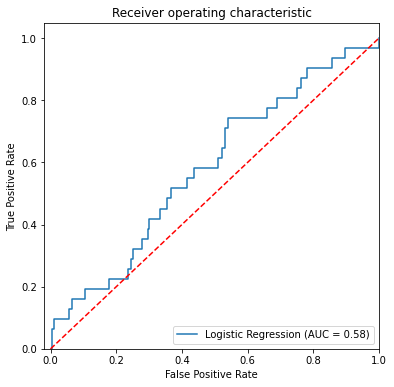

```
----------------------------------------
Classification report:
              precision    recall  f1-score   support

           0       0.94      0.86      0.90       440
           1       0.09      0.19      0.12        31

    accuracy                           0.81       471
   macro avg       0.51      0.53      0.51       471
weighted avg       0.88      0.81      0.84       471

----------------------------------------

Training Data Accuracy Score:	0.97

Test Data Accuracy Score:	0.81

Precision:			0.51

Recall:				0.53

F1 Score:			0.51
----------------------------------------

Confusion Matrix:
[[377  63]
 [ 25   6]]
----------------------------------------
```

```python
from sklearn.model_selection import train_test_split,GridSearchCV

# Logistic Regression with Grid Search
grid_values = {'penalty': ['l1', 'l2'],'C':[0.001,0.01,0.1,1,5,10,25]}
lr3 = LogisticRegression()
grid_lr3 = GridSearchCV(lr3, param_grid = grid_values,scoring = 'f1_micro')
grid_lr3.fit(X_train_scaled,y_train_SM)

print("\nBest params using grid search :\n", grid_lr3.best_params_)

# Fitting GradientBoostingClassifier with best parameters.
lr_best = LogisticRegression(random_state=0, **grid_lr3.best_params_)

# Fit the model
lr_best.fit(X_train_scaled,y_train_SM)

# Predict on Train and Test
y_test_pred = lr_best.predict(X_test_scaled)
y_train_pred = lr_best.predict(X_train_scaled)

#Plotting ROC and AUC
probs = lr_best.predict_proba(X_test_scaled)
preds = probs[:,1]
fpr, tpr, threshold = metrics.roc_curve(y_test, preds)
roc_auc_lr_best = metrics.auc(fpr, tpr)
plt.plot(fpr, tpr, label='Logistic Regression (AUC = %0.2f)' % roc_auc_lr_best)
plt.plot([0, 1], [0, 1],'r--')
plt.xlim([-0.02, 1.0])
plt.ylim([0.0, 1.05])
plt.xlabel('False Positive Rate')
plt.ylabel('True Positive Rate')
plt.title('Receiver operating characteristic')
plt.legend(loc="lower right")
plt.show()

# Evaluating Performance
evaluate_model_perf('LogReg Best Params',y_train_SM, y_train_pred, y_test, y_test_pred)
```

**D. Use any other technique/method which can enhance the model performance**

Due to multiple features in the dataframe, we can have Curse of Dimensionality issue. PCA can be used to apply Dimensionality reduction technique.

```python
from sklearn.decomposition import PCA
pca = PCA(n_components=50)
pca.fit(X_train_SM)
```

```
PCA(n_components=50)
```

```python
np.cumsum(pca.explained_variance_ratio_)
```

```
array([0.60013502, 0.81400691, 0.91884283, 0.94029814, 0.94688309,
       0.95225771, 0.95699409, 0.96141761, 0.96557642, 0.96939185,
       0.97315104, 0.97679894, 0.98003976, 0.98274049, 0.98533539,
       0.98784892, 0.99002895, 0.99190618, 0.99331221, 0.9944012 ,
       0.99547385, 0.99641291, 0.99721916, 0.99791257, 0.99856242,
       0.99895603, 0.99914132, 0.99929163, 0.99940012, 0.99948938,
       0.99957347, 0.99964432, 0.99970991, 0.9997463 , 0.99978077,
       0.99981098, 0.99983545, 0.99985819, 0.99987873, 0.99989722,
       0.99991406, 0.99993001, 0.99994352, 0.99995638, 0.9999668 ,
       0.9999759 , 0.99997887, 0.99998168, 0.99998444, 0.99998655])
```

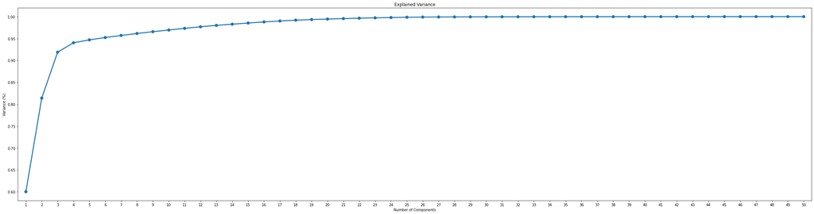

```python
# generating the covariance matrix and the eigen values for the PCA analysis
cov_matrix = np.cov(X_train_SM.T) # the relevanat covariance matrix
#generating the eigen values and the eigen vectors
e_vals, e_vecs = np.linalg.eig(cov_matrix)
# the "cumulative variance explained" analysis
tot = sum(e_vals)
var_exp = [( i /tot ) * 100 for i in sorted(e_vals, reverse=True)]
cum_var_exp = np.cumsum(var_exp)
# Plotting the Cumulative Summation of the Explained Variance
plt.rcParams['figure.figsize'] = (40, 10)
plot = sns.pointplot(x = list(range(1,51)), y = np.cumsum(pca.explained_variance_ratio_))
plot.set_xlabel('Number of Components')
plot.set_ylabel('Variance (%)')
plot.set_title('Explained Variance');
```

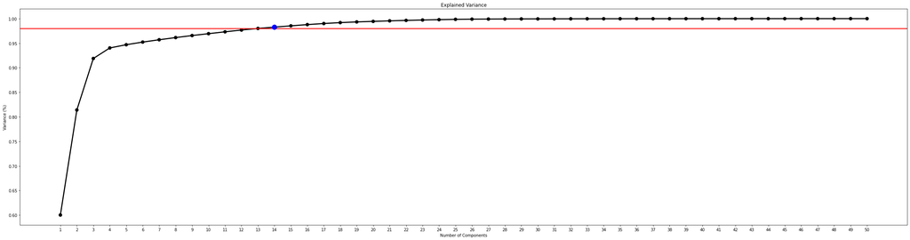

```python
# Plotting the Cumulative Summation of the Explained Variance
plot = sns.pointplot(x = list(range(1,51)), y = np.cumsum(pca.explained_variance_ratio_), color='black')
plot.set_xlabel('Number of Components')
plot.set_ylabel('Variance (%)')
plot.set_title('Explained Variance');
plot.axhline(y=0.98, xmin=0, xmax=9, linewidth=2, color='r')
plot.plot([13], [np.cumsum(pca.explained_variance_ratio_)[13]], "o", markersize = 12, color = 'blue');
```

```python
plt.rcParams['figure.figsize'] = (5, 5)
```

**Observation:**

From the above plot, it is seen that 14 components give more than 98% variance explained. Let us select 14 components to proceed further.

```python
pca_14 = PCA(n_components=14)
X_pca_14 = pca_14.fit_transform(X_train_SM)
X_pca_14.transpose()
```

```
array([[-1055.16655439,  8758.50643893,  5378.03081706, ...,
        -1381.59206095,   394.60530987,  -883.06199403],
       [ 4710.17773505,  -573.83296889, -1980.00023484, ...,
        -1153.24360306,  2914.95137167, -2162.39473607],
       [ -832.28530423, -4116.36604995, -1577.76804578, ...,
         -875.3361029 ,  -655.82705838, -1336.80209498],
       ...,
       [  399.32915449,   907.86693224,  -160.96915046, ...,
           72.49128105,   420.21296007,   199.2482769 ],
       [ -270.90011517,  -144.85320274,   435.16397104, ...,
         -134.2178896 ,   245.8885117 ,  -193.99785702],
       [ -112.48712729,  -238.03293215,   -41.27359196, ...,
          -88.96572134,    69.99630071,    67.91765657]])
```

```python
pca_14_df = pd.DataFrame(data = X_pca_14)
pca_14_df.head()
```

|  | 0 | 1 | 2 | 3 | 4 | 5 | 6 | 7 | 8 | 9 | 10 | 11 | 12 | 13 |
| --- | --- | --- | --- | --- | --- | --- | --- | --- | --- | --- | --- | --- | --- | --- |
| 0 | -1055.166554 | 4710.177735 | -832.285304 | 60.779632 | 75.860446 | 97.518586 | -13.896943 | 442.540192 | 447.675724 | 343.153584 | -464.436545 | 399.329154 | -270.900115 | -112.487127 |
| 1 | 8758.506439 | -573.832969 | -4116.366050 | 922.464606 | -631.989281 | -194.984270 | 537.357615 | -587.554459 | 467.761256 | 456.537139 | 321.547809 | 907.866932 | -144.853203 | -238.032932 |
| 2 | 5378.030817 | -1980.000235 | -1577.768046 | -173.227187 | -395.186576 | 190.543521 | 142.260176 | -156.171750 | 511.598853 | -226.239332 | -396.536850 | -160.969150 | 435.163971 | -41.273592 |
| 3 | -2313.081384 | -2817.344052 | 409.334871 | 233.206986 | -813.151116 | 320.494223 | -209.833932 | -161.212269 | -215.306420 | -310.241046 | -186.047830 | -215.765466 | -229.751451 | -443.739139 |
| 4 | -3097.138266 | -821.843111 | 1454.232570 | -574.453150 | -532.821022 | -210.974203 | 342.448636 | -455.850937 | 446.159075 | 392.051017 | 250.980160 | -391.855407 | 40.689890 | 838.925213 |

```python
pca_14_df.shape
```

```
(2046, 14)
```

```python
# Apply Std Scalar on train data
X_train_PCA = scaler.transform(X_train_SM)
```

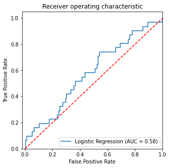

```python
# LogReg Best Param + PCA

# Fitting GradientBoostingClassifier with best parameters.
lr_best_pca = LogisticRegression(random_state=0, **grid_lr3.best_params_)

# Fit the model
lr_best_pca.fit(X_train_PCA,y_train_SM)

# Predict on Train and Test
y_test_pred = lr_best_pca.predict(X_test_scaled)
y_train_pred = lr_best_pca.predict(X_train_PCA)

#Plotting ROC and AUC
probs = lr_best_pca.predict_proba(X_test_scaled)
preds = probs[:,1]
fpr, tpr, threshold = metrics.roc_curve(y_test, preds)
roc_auc_lr_best_pca = metrics.auc(fpr, tpr)
plt.plot(fpr, tpr, label='Logistic Regression (AUC = %0.2f)' % roc_auc_lr_best_pca)
plt.plot([0, 1], [0, 1],'r--')
plt.xlim([-0.02, 1.0])
plt.ylim([0.0, 1.05])
plt.xlabel('False Positive Rate')
plt.ylabel('True Positive Rate')
plt.title('Receiver operating characteristic')
plt.legend(loc="lower right")
plt.show()
```

**E. Display and explain the classification report in detail.**

```python
# Evaluating Performance
evaluate_model_perf('LogReg Best Param + PCA',y_train_SM, y_train_pred, y_test, y_test_pred)
```

```
----------------------------------------
Classification report:
              precision    recall  f1-score   support

           0       0.94      0.86      0.90       440
           1       0.09      0.19      0.12        31

    accuracy                           0.81       471
   macro avg       0.51      0.53      0.51       471
weighted avg       0.88      0.81      0.84       471

----------------------------------------

Training Data Accuracy Score:	0.97

Test Data Accuracy Score:	0.81

Precision:			0.51

Recall:				0.53

F1 Score:			0.51
----------------------------------------

Confusion Matrix:
[[377  63]
 [ 25   6]]
----------------------------------------
```

```python
display_model_matrix()
```

```
--------------------------------------------------------------------------------
Model Performance Comparision Matrix
--------------------------------------------------------------------------------
                     Model  Train Accuracy  Test Accuracy  Precision  \
1       LogReg Best Params       97.018573      81.316348  51.238373
2  LogReg Best Param + PCA       97.018573      81.316348  51.238373
0              LogReg Base       96.187683      81.104034  51.168507

      Recall   F1 Score
1  52.518328  50.774347
2  52.518328  50.774347
0  52.404692  50.649274
--------------------------------------------------------------------------------
```

**Performance Metrics Analysis:**

Logistic Regression base model seems to do already better and gives 96% accuracy on train data.

Test accuracy of 81%, Precision 51%, Recall 52.5%, F1 Score of 50.% is almost the same with/without any tuning on LR model.

Neither PCA nor Hyper parameter tuning was of much help here as the score remained almost the same as base model. Only 1% increase in train accuracy is seen else no much improvement.

**F. Apply the above steps for all possible models that you have learnt so far.**

For classification problem, lets use below models:

1. Logistic Regression
2. SVC
3. Naive Bayes
4. Decision Tree Classifier
5. Random Forest Classifier
6. Adaptive Boosting
7. Gradient Boosting

```python
# SVC - Support Vector Classifier base Model
from sklearn.svm import SVC
svc1 = SVC()
svc1.fit(X_train_scaled,y_train_SM)
y_test_pred = svc1.predict(X_test_scaled)
y_train_pred = svc1.predict(X_train_scaled)

evaluate_model_perf('SVC Base',y_train_SM, y_train_pred, y_test, y_test_pred)
```

```
----------------------------------------
Classification report:
              precision    recall  f1-score   support

           0       0.94      1.00      0.97       440
           1       0.75      0.10      0.17        31

    accuracy                           0.94       471
   macro avg       0.85      0.55      0.57       471
weighted avg       0.93      0.94      0.92       471

----------------------------------------

Training Data Accuracy Score:	1.00

Test Data Accuracy Score:	0.94

Precision:			0.85

Recall:				0.55

F1 Score:			0.57
----------------------------------------

Confusion Matrix:
[[439   1]
 [ 28   3]]
----------------------------------------
```

```python
# Naive Bayes classifier
from sklearn.naive_bayes import GaussianNB
NB1 = GaussianNB()
NB1.fit(X_train_scaled,y_train_SM)
y_test_pred = NB1.predict(X_test_scaled)
y_train_pred = NB1.predict(X_train_scaled)
evaluate_model_perf('Naive Bayes Base',y_train_SM, y_train_pred, y_test, y_test_pred)
```

```
----------------------------------------
Classification report:
              precision    recall  f1-score   support

           0       0.94      0.94      0.94       440
           1       0.15      0.16      0.16        31

    accuracy                           0.89       471
   macro avg       0.55      0.55      0.55       471
weighted avg       0.89      0.89      0.89       471

----------------------------------------

Training Data Accuracy Score:	0.89

Test Data Accuracy Score:	0.89

Precision:			0.55

Recall:				0.55

F1 Score:			0.55
----------------------------------------

Confusion Matrix:
[[412  28]
 [ 26   5]]
----------------------------------------
```

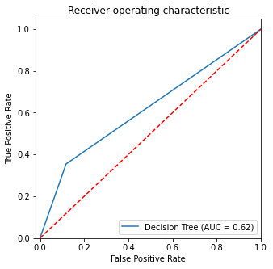

```
----------------------------------------
Classification report:
              precision    recall  f1-score   support

           0       0.95      0.88      0.92       440
           1       0.17      0.35      0.23        31

    accuracy                           0.85       471
   macro avg       0.56      0.62      0.57       471
weighted avg       0.90      0.85      0.87       471

----------------------------------------

Training Data Accuracy Score:	1.00

Test Data Accuracy Score:	0.85

Precision:			0.56

Recall:				0.62

F1 Score:			0.57
----------------------------------------

Confusion Matrix:
[[388  52]
 [ 20  11]]
----------------------------------------
```

```python
# Decision Tree Classifier
# Choose only max_depth pruning as hyper parameter to avoid overfitting.
from sklearn.tree import DecisionTreeClassifier
from sklearn.model_selection import train_test_split,GridSearchCV,StratifiedKFold,KFold

DTC1 = DecisionTreeClassifier()
param_grid = {'max_depth':[10,20,30,40]}
skf = StratifiedKFold(n_splits=5)
gs1 = GridSearchCV(estimator=DTC1,param_grid = param_grid,cv=skf,scoring = 'f1_micro' )
gs1.fit(X_train_scaled,y_train_SM)
y_test_pred = gs1.predict(X_test_scaled)
y_train_pred = gs1.predict(X_train_scaled)

#Plotting ROC and AUC
probs = gs1.predict_proba(X_test_scaled)
preds = probs[:,1]
fpr, tpr, threshold = metrics.roc_curve(y_test, preds)
roc_auc_gs1 = metrics.auc(fpr, tpr)
plt.plot(fpr, tpr, label='Decision Tree (AUC = %0.2f)' % roc_auc_gs1)
plt.plot([0, 1], [0, 1],'r--')
plt.xlim([-0.02, 1.0])
plt.ylim([0.0, 1.05])
plt.xlabel('False Positive Rate')
plt.ylabel('True Positive Rate')
plt.title('Receiver operating characteristic')
plt.legend(loc="lower right")
plt.show()

evaluate_model_perf('DecisionTree Base',y_train_SM, y_train_pred, y_test, y_test_pred)
```

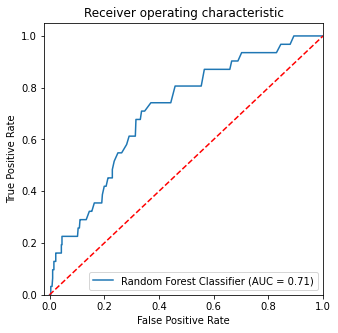

```
----------------------------------------
Classification report:
              precision    recall  f1-score   support

           0       0.93      1.00      0.96       440
           1       0.00      0.00      0.00        31

    accuracy                           0.93       471
   macro avg       0.47      0.50      0.48       471
weighted avg       0.87      0.93      0.90       471

----------------------------------------

Training Data Accuracy Score:	1.00

Test Data Accuracy Score:	0.93

Precision:			0.47

Recall:				0.50

F1 Score:			0.48
----------------------------------------

Confusion Matrix:
[[439   1]
 [ 31   0]]
----------------------------------------
```

```python
# Random Forest Classifier
from sklearn.ensemble import RandomForestClassifier

rfc1 = RandomForestClassifier()
param_grid = {'n_estimators':[100,200,300,400]}
skfrfc1 = StratifiedKFold(n_splits=5)
gs2 = GridSearchCV(estimator=rfc1,param_grid = param_grid,cv=skfrfc1,scoring = 'f1_micro')
gs2.fit(X_train_scaled,y_train_SM)
y_test_pred = gs2.predict(X_test_scaled)
y_train_pred = gs2.predict(X_train_scaled)

#Plotting ROC and AUC
probs = gs2.predict_proba(X_test_scaled)
preds = probs[:,1]
fpr, tpr, threshold = metrics.roc_curve(y_test, preds)
roc_auc_gs2 = metrics.auc(fpr, tpr)
plt.plot(fpr, tpr, label='Random Forest Classifier (AUC = %0.2f)' % roc_auc_gs2)
plt.plot([0, 1], [0, 1],'r--')
plt.xlim([-0.02, 1.0])
plt.ylim([0.0, 1.05])
plt.xlabel('False Positive Rate')
plt.ylabel('True Positive Rate')
plt.title('Receiver operating characteristic')
plt.legend(loc="lower right")
plt.show()

evaluate_model_perf('RandForest Base',y_train_SM, y_train_pred, y_test, y_test_pred)
```

```python
# Adaptive Boosting Base Model
from sklearn.ensemble import AdaBoostClassifier

ada1 = AdaBoostClassifier(n_estimators=100)
ada1.fit(X_train_scaled,y_train_SM)
y_test_pred = ada1.predict(X_test_scaled)
y_train_pred = ada1.predict(X_train_scaled)
evaluate_model_perf('AdaBoost Base',y_train_SM, y_train_pred, y_test, y_test_pred)
```

```
----------------------------------------
Classification report:
              precision    recall  f1-score   support

           0       0.94      0.92      0.93       440
           1       0.10      0.13      0.11        31

    accuracy                           0.87       471
   macro avg       0.52      0.52      0.52       471
weighted avg       0.88      0.87      0.88       471

----------------------------------------

Training Data Accuracy Score:	1.00

Test Data Accuracy Score:	0.87

Precision:			0.52

Recall:				0.52

F1 Score:			0.52
----------------------------------------

Confusion Matrix:
[[405  35]
 [ 27   4]]
----------------------------------------
```

```python
# Gradient Boosting Technique
from sklearn.ensemble import GradientBoostingClassifier

Xgboost1 = GradientBoostingClassifier(n_estimators=100)
Xgboost1.fit(X_train_scaled,y_train_SM)
y_test_pred = Xgboost1.predict(X_test_scaled)
y_train_pred = Xgboost1.predict(X_train_scaled)
evaluate_model_perf('GradBoosting Base',y_train_SM, y_train_pred, y_test, y_test_pred)
```

```
----------------------------------------
Classification report:
              precision    recall  f1-score   support

           0       0.94      0.98      0.96       440
           1       0.23      0.10      0.14        31

    accuracy                           0.92       471
   macro avg       0.58      0.54      0.55       471
weighted avg       0.89      0.92      0.90       471

----------------------------------------

Training Data Accuracy Score:	1.00

Test Data Accuracy Score:	0.92

Precision:			0.58

Recall:				0.54

F1 Score:			0.55
----------------------------------------

Confusion Matrix:
[[430  10]
 [ 28   3]]
----------------------------------------
```

```python
display_model_matrix()
```

```
--------------------------------------------------------------------------------
Model Performance Comparision Matrix
--------------------------------------------------------------------------------
                     Model  Train Accuracy  Test Accuracy  Precision  \
5        DecisionTree Base      100.000000      84.713376  56.279178
3                 SVC Base      100.000000      93.842887  84.502141
4         Naive Bayes Base       89.002933      88.535032  54.607721
8        GradBoosting Base      100.000000      91.932059  58.481693
7            AdaBoost Base      100.000000      86.836518  52.003205
1       LogReg Best Params       97.018573      81.316348  51.238373
2  LogReg Best Param + PCA       97.018573      81.316348  51.238373
0              LogReg Base       96.187683      81.104034  51.168507
6          RandForest Base      100.000000      93.205945  46.702128

      Recall   F1 Score
5  61.832845  57.456845
3  54.725073  56.972752
4  54.882698  54.737329
8  53.702346  54.702369
7  52.474340  52.159240
1  52.518328  50.774347
2  52.518328  50.774347
0  52.404692  50.649274
6  49.886364  48.241758
--------------------------------------------------------------------------------
```

```python
kfold= KFold(n_splits=num_folds, random_state=seed, shuffle=True)
NB2 = GaussianNB()
results = cross_val_score(NB2, X_train_scaled,y_train_SM, cv=kfold)
print("Accuracy for GaussianNB: %.3f%% with SD of %.3f%%" % (results.mean()*100.0, results.std()*100.0))
```

```
Accuracy for GaussianNB: 88.263% with SD of 4.878%
```

```python
kfold= KFold(n_splits=num_folds, random_state=seed, shuffle=True)
ada2 = AdaBoostClassifier(n_estimators=100)
results = cross_val_score(ada2, X_train_scaled,y_train_SM, cv=kfold)
print("Accuracy for AdaBoostClassifier: %.3f%% with SD of %.3f%%" % (results.mean()*100.0, results.std()*100.0))
```

```
Accuracy for AdaBoostClassifier: 95.504% with SD of 3.181%
```

```python
kfold= KFold(n_splits=num_folds, random_state=seed, shuffle=True)
Xgboost2 = GradientBoostingClassifier(n_estimators=100)
results = cross_val_score(Xgboost2, X_train_scaled,y_train_SM, cv=kfold)
print("Accuracy for GradientBoostingClassifier: %.3f%% with SD of %.3f%%" % (results.mean()*100.0, results.std()*100.0))
```

```
Accuracy for GradientBoostingClassifier: 97.460% with SD of 2.286%
```

```
Best params using grid search :
 {'ccp_alpha': 0.001, 'criterion': 'entropy', 'max_depth': 9, 'max_features': 'sqrt'}
```

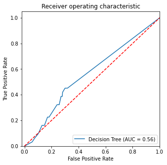

```
----------------------------------------
Classification report:
              precision    recall  f1-score   support

           0       0.94      0.75      0.83       440
           1       0.08      0.32      0.13        31

    accuracy                           0.72       471
   macro avg       0.51      0.53      0.48       471
weighted avg       0.88      0.72      0.79       471

----------------------------------------

Training Data Accuracy Score:	0.93

Test Data Accuracy Score:	0.72

Precision:			0.51

Recall:				0.53

F1 Score:			0.48
----------------------------------------

Confusion Matrix:
[[328 112]
 [ 21  10]]
----------------------------------------
```

```python
# Decision Tree Classifier with Grid Search

DTC2 = DecisionTreeClassifier()
param_grid =  {'max_features': ['auto', 'sqrt', 'log2'],
              'ccp_alpha': [0.1, .01, .001],
              'max_depth' : [5, 6, 7, 8, 9],
              'criterion' :['gini', 'entropy']
             }
skf = StratifiedKFold(n_splits=5)
dtc_grid = GridSearchCV(estimator=DTC2,param_grid = param_grid,cv=skf,scoring = 'f1_micro')
dtc_grid.fit(X_train_scaled,y_train_SM)

print("\nBest params using grid search :\n", dtc_grid.best_params_)
dtc_best = DecisionTreeClassifier(random_state=0, **dtc_grid.best_params_)

# Fit the model
dtc_best.fit(X_train_scaled,y_train_SM)
y_test_pred = dtc_best.predict(X_test_scaled)
y_train_pred = dtc_best.predict(X_train_scaled)

#Plotting ROC and AUC
probs = dtc_best.predict_proba(X_test_scaled)
preds = probs[:,1]
fpr, tpr, threshold = metrics.roc_curve(y_test, preds)
roc_auc_gs1 = metrics.auc(fpr, tpr)
plt.plot(fpr, tpr, label='Decision Tree (AUC = %0.2f)' % roc_auc_gs1)
plt.plot([0, 1], [0, 1],'r--')
plt.xlim([-0.02, 1.0])
plt.ylim([0.0, 1.05])
plt.xlabel('False Positive Rate')
plt.ylabel('True Positive Rate')
plt.title('Receiver operating characteristic')
plt.legend(loc="lower right")
plt.show()
evaluate_model_perf('DecisionTree Best Params',y_train_SM, y_train_pred, y_test, y_test_pred)
```

```
Best params using grid search :
 {'criterion': 'gini', 'max_depth': 8, 'max_features': 'log2', 'n_estimators': 500}
```

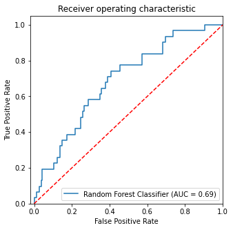

```
----------------------------------------
Classification report:
              precision    recall  f1-score   support

           0       0.94      0.96      0.95       440
           1       0.16      0.10      0.12        31

    accuracy                           0.91       471
   macro avg       0.55      0.53      0.54       471
weighted avg       0.89      0.91      0.90       471

----------------------------------------

Training Data Accuracy Score:	1.00

Test Data Accuracy Score:	0.91

Precision:			0.55

Recall:				0.53

F1 Score:			0.54
----------------------------------------

Confusion Matrix:
[[424  16]
 [ 28   3]]
----------------------------------------
```

```python
# Random Forest Classifier with Grid Search

param_grid = {
    'n_estimators': [200, 500],
    'max_features': ['auto', 'sqrt', 'log2'],
    'max_depth' : [4,5,6,7,8],
    'criterion' :['gini', 'entropy']
}

rfc2 = RandomForestClassifier()
skfrfc1 = StratifiedKFold(n_splits=5)
rfc_gs2 = GridSearchCV(estimator=rfc2,param_grid = param_grid,cv=skfrfc1 ,scoring = 'f1_micro', n_jobs=-1 )
rfc_gs2.fit(X_train_scaled,y_train_SM)

print("\nBest params using grid search :\n", rfc_gs2.best_params_)
rfc_best = RandomForestClassifier(random_state=0, **rfc_gs2.best_params_)
# Fit the model
rfc_best.fit(X_train_scaled,y_train_SM)
y_test_pred = rfc_best.predict(X_test_scaled)
y_train_pred = rfc_best.predict(X_train_scaled)

#Plotting ROC and AUC
probs = rfc_best.predict_proba(X_test_scaled)
preds = probs[:,1]
fpr, tpr, threshold = metrics.roc_curve(y_test, preds)
roc_auc_gs1 = metrics.auc(fpr, tpr)
plt.plot(fpr, tpr, label='Random Forest Classifier (AUC = %0.2f)' % roc_auc_gs1)
plt.plot([0, 1], [0, 1],'r--')
plt.xlim([-0.02, 1.0])
plt.ylim([0.0, 1.05])
plt.xlabel('False Positive Rate')
plt.ylabel('True Positive Rate')
plt.title('Receiver operating characteristic')
plt.legend(loc="lower right")
plt.show()
evaluate_model_perf('RandForest Best Params',y_train_SM, y_train_pred, y_test, y_test_pred)
```

```python
# AdaBoostClassifier with Grid Search

grid = dict()
grid['n_estimators'] = [10, 20, 30]
grid['learning_rate'] = [0.01, 0.1, 1.0]

ada3 = AdaBoostClassifier()
grid_ada3 = GridSearchCV(ada3, param_grid = grid,scoring = 'f1_micro', n_jobs=-1 )
grid_ada3.fit(X_train_scaled,y_train_SM)

print("\nBest params using grid search :\n", grid_ada3.best_params_)

# Fitting GradientBoostingClassifier with best parameters.
ada_best = AdaBoostClassifier(random_state=0, **grid_ada3.best_params_)

# Fit the model
ada_best.fit(X_train_scaled,y_train_SM)

# Predict on Train and Test
y_test_pred = ada_best.predict(X_test_scaled)
y_train_pred = ada_best.predict(X_train_scaled)

# Evaluating Performance
evaluate_model_perf('AdaBoosting Best Params',y_train_SM, y_train_pred, y_test, y_test_pred)
```

```
Best params using grid search :
 {'learning_rate': 1.0, 'n_estimators': 30}
----------------------------------------
Classification report:
              precision    recall  f1-score   support

           0       0.94      0.90      0.92       440
           1       0.10      0.16      0.13        31

    accuracy                           0.85       471
   macro avg       0.52      0.53      0.52       471
weighted avg       0.88      0.85      0.87       471

----------------------------------------

Training Data Accuracy Score:	0.94

Test Data Accuracy Score:	0.85

Precision:			0.52

Recall:				0.53

F1 Score:			0.52
----------------------------------------

Confusion Matrix:
[[396  44]
 [ 26   5]]
----------------------------------------
```

```python
# Gradient Boosting with Grid Search

parameters = {
    "loss":["deviance"],
    "learning_rate": [0.01, 0.05, 0.1],
    "min_samples_leaf": np.linspace(0.1, 0.5, 1),
    "max_depth":[3,4,5],
    "max_features":["log2","sqrt"],
    "n_estimators":[10]
    }
Xgboost3 = GradientBoostingClassifier()
grid_Xgboost3 = GridSearchCV(Xgboost3, param_grid = parameters,scoring = 'f1_micro', n_jobs=-1 )
grid_Xgboost3.fit(X_train_scaled,y_train_SM)

print("\nBest params using grid search :\n", grid_Xgboost3.best_params_)

# Fitting GradientBoostingClassifier with best parameters.
Xgboost_best = GradientBoostingClassifier(random_state=0, **grid_Xgboost3.best_params_)

# Fit the model
Xgboost_best.fit(X_train_scaled,y_train_SM)

# Predict on Train and Test
y_test_pred = Xgboost_best.predict(X_test_scaled)
y_train_pred = Xgboost_best.predict(X_train_scaled)

# Evaluating Performance
evaluate_model_perf('GradBoosting Best Params',y_train_SM, y_train_pred, y_test, y_test_pred)
```

```
Best params using grid search :
 {'learning_rate': 0.1, 'loss': 'deviance', 'max_depth': 5, 'max_features': 'sqrt', 'min_samples_leaf': 0.1, 'n_estimators': 10}
----------------------------------------
Classification report:
              precision    recall  f1-score   support

           0       0.94      0.85      0.89       440
           1       0.08      0.19      0.11        31

    accuracy                           0.80       471
   macro avg       0.51      0.52      0.50       471
weighted avg       0.88      0.80      0.84       471

----------------------------------------

Training Data Accuracy Score:	0.87

Test Data Accuracy Score:	0.80

Precision:			0.51

Recall:				0.52

F1 Score:			0.50
----------------------------------------

Confusion Matrix:
[[372  68]
 [ 25   6]]
----------------------------------------
```

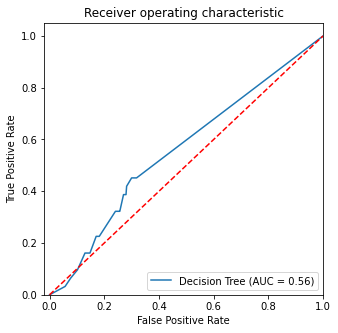

```
----------------------------------------
Classification report:
              precision    recall  f1-score   support

           0       0.94      0.75      0.83       440
           1       0.08      0.32      0.13        31

    accuracy                           0.72       471
   macro avg       0.51      0.53      0.48       471
weighted avg       0.88      0.72      0.79       471

----------------------------------------

Training Data Accuracy Score:	0.93

Test Data Accuracy Score:	0.72

Precision:			0.51

Recall:				0.53

F1 Score:			0.48
----------------------------------------

Confusion Matrix:
[[328 112]
 [ 21  10]]
----------------------------------------
```

```python
# Decision Tree with Grid Search Best Params and PCA

# Fit the model
dtc_best_pca = DecisionTreeClassifier(random_state=0, **dtc_grid.best_params_)
dtc_best_pca.fit(X_train_PCA,y_train_SM)
y_test_pred = dtc_best_pca.predict(X_test_scaled)
y_train_pred = dtc_best_pca.predict(X_train_PCA)

#Plotting ROC and AUC
probs = dtc_best_pca.predict_proba(X_test_scaled)
preds = probs[:,1]
fpr, tpr, threshold = metrics.roc_curve(y_test, preds)
roc_auc_gs1 = metrics.auc(fpr, tpr)
plt.plot(fpr, tpr, label='Decision Tree (AUC = %0.2f)' % roc_auc_gs1)
plt.plot([0, 1], [0, 1],'r--')
plt.xlim([-0.02, 1.0])
plt.ylim([0.0, 1.05])
plt.xlabel('False Positive Rate')
plt.ylabel('True Positive Rate')
plt.title('Receiver operating characteristic')
plt.legend(loc="lower right")
plt.show()
evaluate_model_perf('DecTree Best Param + PCA',y_train_SM, y_train_pred, y_test, y_test_pred)
```

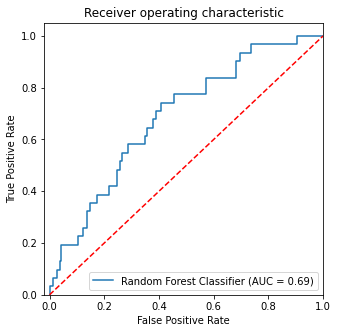

```
----------------------------------------
Classification report:
              precision    recall  f1-score   support

           0       0.94      0.96      0.95       440
           1       0.16      0.10      0.12        31

    accuracy                           0.91       471
   macro avg       0.55      0.53      0.54       471
weighted avg       0.89      0.91      0.90       471

----------------------------------------

Training Data Accuracy Score:	1.00

Test Data Accuracy Score:	0.91

Precision:			0.55

Recall:				0.53

F1 Score:			0.54
----------------------------------------

Confusion Matrix:
[[424  16]
 [ 28   3]]
----------------------------------------
```

```python
# Random Forest with Grid Search Best Params and PCA
# Fit the model
rfc_best_pca = RandomForestClassifier(random_state=0, **rfc_gs2.best_params_)
rfc_best_pca.fit(X_train_PCA,y_train_SM)
y_test_pred = rfc_best_pca.predict(X_test_scaled)
y_train_pred = rfc_best_pca.predict(X_train_PCA)

#Plotting ROC and AUC
probs = rfc_best_pca.predict_proba(X_test_scaled)
preds = probs[:,1]
fpr, tpr, threshold = metrics.roc_curve(y_test, preds)
roc_auc_gs1 = metrics.auc(fpr, tpr)
plt.plot(fpr, tpr, label='Random Forest Classifier (AUC = %0.2f)' % roc_auc_gs1)
plt.plot([0, 1], [0, 1],'r--')
plt.xlim([-0.02, 1.0])
plt.ylim([0.0, 1.05])
plt.xlabel('False Positive Rate')
plt.ylabel('True Positive Rate')
plt.title('Receiver operating characteristic')
plt.legend(loc="lower right")
plt.show()
evaluate_model_perf('RandForest Best Params + PCA',y_train_SM, y_train_pred, y_test, y_test_pred)
```

```python
# Adaptive Boosting with Grid Search Best Params and PCA
# Fit the model
ada_best_pca = AdaBoostClassifier(random_state=0, **grid_ada3.best_params_)
ada_best_pca.fit(X_train_PCA,y_train_SM)

# Predict on Train and Test
y_test_pred = ada_best_pca.predict(X_test_scaled)
y_train_pred = ada_best_pca.predict(X_train_PCA)

# Evaluating Performance
evaluate_model_perf('AdaBoost Best Params + PCA',y_train_SM, y_train_pred, y_test, y_test_pred)
```

```
----------------------------------------
Classification report:
              precision    recall  f1-score   support

           0       0.94      0.90      0.92       440
           1       0.10      0.16      0.13        31

    accuracy                           0.85       471
   macro avg       0.52      0.53      0.52       471
weighted avg       0.88      0.85      0.87       471

----------------------------------------

Training Data Accuracy Score:	0.94

Test Data Accuracy Score:	0.85

Precision:			0.52

Recall:				0.53

F1 Score:			0.52
----------------------------------------

Confusion Matrix:
[[396  44]
 [ 26   5]]
----------------------------------------
```

```python
# Gradient Boosting with Grid Search Best Params and PCA
# Fit the model
Xgboost_best_pca = GradientBoostingClassifier(random_state=0, **grid_Xgboost3.best_params_)
Xgboost_best_pca.fit(X_train_PCA,y_train_SM)

# Predict on Train and Test
y_test_pred = Xgboost_best_pca.predict(X_test_scaled)
y_train_pred = Xgboost_best_pca.predict(X_train_PCA)

# Evaluating Performance
evaluate_model_perf('GradBoost Best Params + PCA',y_train_SM, y_train_pred, y_test, y_test_pred)
```

```
----------------------------------------
Classification report:
              precision    recall  f1-score   support

           0       0.94      0.85      0.89       440
           1       0.08      0.19      0.11        31

    accuracy                           0.80       471
   macro avg       0.51      0.52      0.50       471
weighted avg       0.88      0.80      0.84       471

----------------------------------------

Training Data Accuracy Score:	0.87

Test Data Accuracy Score:	0.80

Precision:			0.51

Recall:				0.52

F1 Score:			0.50
----------------------------------------

Confusion Matrix:
[[372  68]
 [ 25   6]]
----------------------------------------
```

## **6. Post Training and Conclusion:**

**A. Display and compare all the models designed with their train and test accuracies.**

```python
display_model_matrix()
```

```
--------------------------------------------------------------------------------
Model Performance Comparision Matrix
--------------------------------------------------------------------------------
                           Model  Train Accuracy  Test Accuracy  Precision  \
5              DecisionTree Base      100.000000      84.713376  56.279178
3                       SVC Base      100.000000      93.842887  84.502141
4               Naive Bayes Base       89.002933      88.535032  54.607721
8              GradBoosting Base      100.000000      91.932059  58.481693
14  RandForest Best Params + PCA       99.853372      90.658174  54.797392
10        RandForest Best Params       99.853372      90.658174  54.797392
11       AdaBoosting Best Params       94.183773      85.138004  52.021472
15    AdaBoost Best Params + PCA       94.183773      85.138004  52.021472
7                  AdaBoost Base      100.000000      86.836518  52.003205
2        LogReg Best Param + PCA       97.018573      81.316348  51.238373
1             LogReg Best Params       97.018573      81.316348  51.238373
```

[output cut: 26 more lines]

**B. Select the final best trained model along with your detailed comments for selecting this model.**

**Final Model Selection Analysis:**

1. DecisionTree Base, SVC Base, GradBoosting Base, AdaBoost Base and RandForest Base seem to be overfit model as train accuracy is 100%. So we will skip them.
2. RandForest Best Params + PCA and RandForest Best Params both are almost overfitting model. Skip them.
3. Next best model seems to be AdaBoost Best Params + PCA with 94% train Accuracy, 85% test accuracy. The variance is also not much and fares well at F1 score. For our classification problem, we need to strike a balance between precision and recall. Hence F1 score is of importance here.

```python
import pickle
# Fit the Final model
final_model = AdaBoostClassifier(random_state=0, **grid_ada3.best_params_)
final_model.fit(X_train_PCA,y_train_SM)
y_train_pred = final_model.predict(X_train_PCA)
y_test_pred = final_model.predict(X_test_scaled)
```

**C. Pickle the selected model for future use.**

```python
####################### Pickle the Final model for future prediction ##########################
# Save the Model to file in the current working directory
def save_pickle(classifier):
  best_classifier_file = "Pickle_ADA_Model.pkl"
  with open(best_classifier_file, 'wb') as file:
    pickle.dump(classifier, file)
  return best_classifier_file

# Load the Model back from file
def load_pickle(best_classifier_file):
  with open(best_classifier_file, 'rb') as file:
    Pickle_ADA_Model = pickle.load(file)
  print(Pickle_ADA_Model)

# Save best classifier as pickle file
final_model_file = save_pickle(final_model)

# Load for verification Purpose
load_pickle(final_model_file)
```

```
AdaBoostClassifier(n_estimators=30, random_state=0)
```

**D. Write your conclusion on the results.**